# Module 2 Summary: Python Fundamentals – Variables, Data Types, and Arithmetic Operations

Author

Affiliation

Dr. Smith

University of South Florida

# Module 2 Overview

This document provides a concise summary of what we covered in Module 2, which built upon the foundation laid in Module 1 by diving deeper into variables, data types, and arithmetic operations in Python, with a focus on business applications.

## What We Learned

In Module 2, we covered:

1. **Variables and data types**: How to create, name, and use different types of business data
2. **Type conversion**: Converting between different data types as needed
3. **Arithmetic operations**: Performing calculations with Python’s operators
4. **Order of operations**: Understanding how Python evaluates expressions
5. **Math library**: Using specialized mathematical functions for business calculations
6. **Best practices and common pitfalls**: Writing clear, reliable code and avoiding errors

Let’s review each of these key areas briefly.

## Mind Map: Module 2 Content

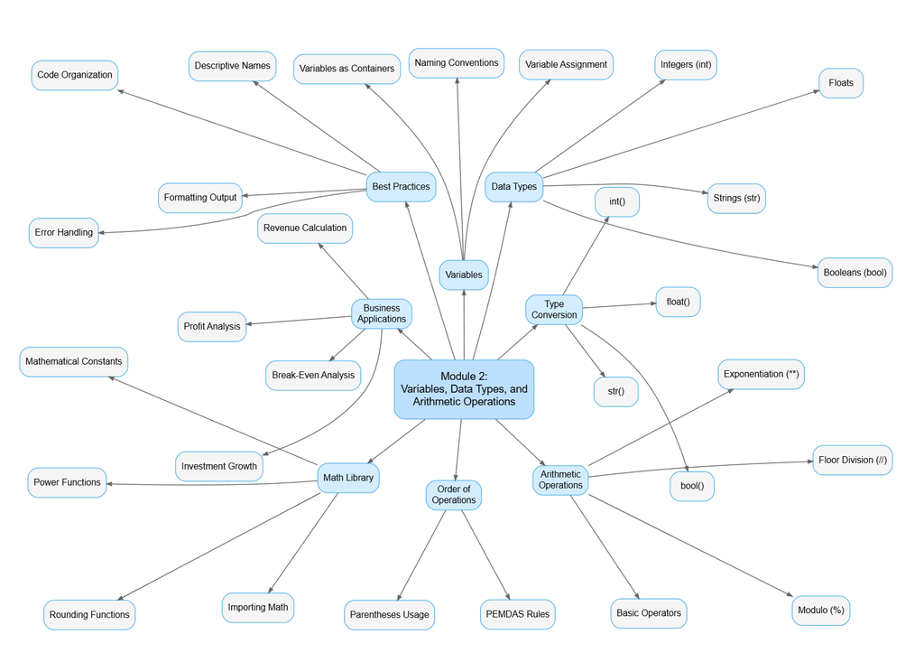

# 1. Variables and Data Types

Variables are the foundation of programming, serving as labeled containers that store different kinds of information. In business contexts, variables represent important data like sales figures, customer counts, and financial metrics.

## Variables as Containers

Think of variables as labeled boxes that hold specific pieces of information:

```
 ┌─────────────────┐
 │ total_revenue   │
 ├─────────────────┤
 │     190000      │
 └─────────────────┘
```

## Declaring and Assigning Variables

To create a variable in Python, you assign a value using the equals sign (`=`):

```python
# Creating business-related variables
company_name = "Tech Innovations Inc."  # A string (text)
quarterly_revenue = 250000              # An integer (whole number)
growth_rate = 0.15                      # A float (decimal number)
is_profitable = True                    # A boolean (True/False)
```

## Variable Naming Best Practices

Good variable names are crucial for readable code:

- Use descriptive names that explain what the variable contains
- Follow snake_case convention (lowercase with underscores between words)
- Start with a letter or underscore, not a number
- Avoid using Python’s reserved keywords
- Be consistent with your naming style

**Compare These Examples**

Instead of `r = 45000`, use `quarterly_revenue = 45000`

Instead of `q1`, `q2`, `q3`, `q4`, use `q1_sales`, `q2_sales`, `q3_sales`, `q4_sales`

## Core Data Types

Python has several built-in data types to represent different kinds of information:

| Data Type | Example | Description | Business Use Cases |
| --- | --- | --- | --- |
| **int** | `150` | Whole numbers without decimals | Inventory counts, employee numbers, days |
| **float** | `299.99` | Numbers with decimals | Prices, profit margins, financial ratios |
| **str** | `"USF"` | Text enclosed in quotes | Names, product descriptions, categories |
| **bool** | `True`/`False` | Represents truth values | In-stock status, eligibility flags, approvals |

# 2. Type Conversion

Often in business applications, you’ll need to convert between different data types—for example, when processing user input or preparing data for calculations.

## Conversion Functions

Python provides built-in functions to convert between data types:

```python
# Examples of type conversion in business contexts
id_as_string = "1001"
id_as_number = int(id_as_string)      # Convert to integer

price_string = "29.99"
price = float(price_string)           # Convert to float

quantity = 150
quantity_text = str(quantity)         # Convert to string

in_stock = bool(quantity)             # Convert to boolean (True if non-zero)
```

## When and Why to Convert Types

Type conversion is necessary when:

- Processing user input (which comes in as strings)
- Reading data from files or databases
- Performing calculations with data of different types
- Displaying numeric results as formatted text

**Conversion Pitfalls to Avoid**

- `int("29.99")` will cause an error – you need to use `int(float("29.99"))` or just keep it as a float
- `int("one hundred")` will fail because the string doesn’t represent a number
- Empty strings, zero, and None all convert to `False` when using `bool()`

# 3. Arithmetic Operations

Python provides a comprehensive set of operators for performing business calculations, from simple addition to more complex financial formulas.

## Basic Arithmetic Operators

| Operator | Operation | Example | Result | Business Application |
| --- | --- | --- | --- | --- |
| `+` | Addition | `100 + 25` | `125` | Combining sales from different regions |
| `-` | Subtraction | `100 - 25` | `75` | Calculating profit (revenue - costs) |
| `*` | Multiplication | `100 * 0.25` | `25` | Applying a percentage (e.g., tax, discount) |
| `/` | Division | `100 / 4` | `25.0` | Finding per-unit metrics |
| `**` | Exponentiation (Power) | `1.05 ** 3` | `1.1576` | Compound growth calculations |
| `%` | Modulo (Remainder) | `15 % 4` | `3` | Inventory and resource allocation |
| `//` | Floor Division | `15 // 4` | `3` | Determining complete units or batches |

## Special Business Uses for Modulo and Floor Division

The modulo (`%`) and floor division (`//`) operators are particularly useful in business contexts:

```python
# Inventory management example
total_items = 237
items_per_container = 40

# How many full containers can we ship?
full_containers = total_items // items_per_container  # 5

# How many items will be left over?
remaining_items = total_items % items_per_container   # 37

print(f"Ship {full_containers} full containers with {remaining_items} items left over")
```

## Order of Operations

Python follows the standard mathematical order of operations (PEMDAS/BODMAS):

1. **Parentheses ( )** – Operations inside parentheses are performed first
2. **Exponents (`**`)** – Evaluated next
3. **Multiplication, Division, Floor Division, and Modulo (`*`, `/`, `//`, `%`)** – From left to right
4. **Addition and Subtraction (`+`, `-`)** – From left to right

```python
# How parentheses affect order of operations
price = 100
tax_rate = 0.07

# Without parentheses - different operation order
result1 = price + price * tax_rate   # 107.0 (multiplication first)

# With parentheses - forcing addition first
result2 = (price + price) * tax_rate  # 14.0 (different result!)
```

**When in Doubt, Use Parentheses**

Even when not strictly necessary, parentheses make your calculations clearer and help prevent mistakes:

```python
# Less clear - relies on order of operations
discount_price = original_price - original_price * discount_rate

# More clear - explicitly shows intent
discount_price = original_price - (original_price * discount_rate)
```

# 4. The Math Library

For more advanced business calculations, Python’s `math` library provides additional functions and constants.

## Importing and Using the Math Library

Before using any function from the math library, you must import it:

```python
import math  # This imports the entire math library
```

## Useful Math Functions for Business

```python
import math

# Rounding functions for financial calculations
price = 19.45
ceiling_price = math.ceil(price)    # 20 (always rounds up)
floor_price = math.floor(price)     # 19 (always rounds down)

# Investment calculations
principal = 10000
rate = 0.05  # 5% annual interest
years = 3
future_value = principal * math.pow(1 + rate, years)  # 11576.25

# Continuous compounding
continuous_value = principal * math.exp(rate * years)  # 11618.34

# Constants
circle_area = math.pi * (radius ** 2)  # Using math.pi (3.14159...)
```

## Math Library Functions for Business

- **Rounding**: `math.ceil()`, `math.floor()`, `round()`
- **Exponentiation**: `math.pow()`, `math.exp()`
- **Logarithms**: `math.log()`, `math.log10()`
- **Constants**: `math.pi`, `math.e`

# 5. Business Applications

Now let’s look at how we can combine these concepts to solve real business problems.

## Revenue, Cost, and Profit Calculation

```python
# Business Calculation: Revenue, Cost, and Profit

# Input data
product_name = "Premium Business Analytics Suite"
units_sold = 150
price_per_unit = 299.99
cost_per_unit = 125.50
fixed_costs = 10000

# Revenue calculation
total_revenue = units_sold * price_per_unit

# Cost calculations
variable_costs = units_sold * cost_per_unit
total_costs = fixed_costs + variable_costs

# Profit calculations
profit = total_revenue - total_costs
profit_margin = (profit / total_revenue) * 100

# Break-even calculation
contribution_per_unit = price_per_unit - cost_per_unit
break_even_units = fixed_costs / contribution_per_unit

# Format and display results
print(f"=== Business Analysis: {product_name} ===")
print(f"Units Sold: {units_sold}")
print(f"Price per Unit: ${price_per_unit}")
print(f"Total Revenue: ${round(total_revenue, 2)}")
print(f"Total Costs: ${round(total_costs, 2)}")
print(f"Profit: ${round(profit, 2)}")
print(f"Profit Margin: {round(profit_margin, 2)}%")
print(f"Break-even Point: {math.ceil(break_even_units)} units")
```

## Investment Growth Calculator

```python
import math

# Investment parameters
principal = 5000        # Initial investment amount
annual_rate = 0.08      # 8% annual return
inflation_rate = 0.03   # 3% annual inflation
years = 10              # Investment period

# Calculate future value (nominal)
future_value = principal * math.pow(1 + annual_rate, years)

# Calculate inflation-adjusted value (real value)
inflation_factor = math.pow(1 + inflation_rate, years)
real_value = future_value / inflation_factor

# Format and display results
print(f"Investment Growth Analysis:")
print(f"Initial Investment: ${principal}")
print(f"Annual Return: {annual_rate*100}%")
print(f"Time Period: {years} years")
print(f"Future Value (nominal): ${round(future_value, 2)}")
print(f"Future Value (inflation-adjusted): ${round(real_value, 2)}")
```

# 6. Best Practices and Common Pitfalls

Writing good code is about more than just getting the right answer—it’s about writing clear, maintainable code that others (and your future self) can understand.

## Best Practices for Business Python Code

1. **Use descriptive variable names:** `monthly_revenue` is better than `mr`
2. **Add helpful comments:** Explain the “why” behind complex calculations
3. **Organize your code into logical sections:** Inputs, calculations, outputs
4. **Use whitespace and indentation consistently:** Makes code more readable
5. **Use parentheses for clarity:** Even when not strictly required
6. **Round financial outputs appropriately:** Use `round()` for display purposes

## Common Pitfalls to Avoid

1. **Type errors in calculations:**

   ```python
   # Common mistake: Adding string and number
   price_as_string = "29.99"
   discount = 5
   # This will cause an error:
   # discounted_price = price_as_string - discount

   # Correct approach:
   price = float(price_as_string)
   discounted_price = price - discount
   ```

2. **Order of operations mistakes:**

   ```python
   # Wrong calculation:
   # final_price = cost + cost * markup_rate + cost * tax_rate
   # This applies tax to the base cost, not the marked-up price!

   # Correct calculation:
   marked_up_price = cost + (cost * markup_rate)
   final_price = marked_up_price + (marked_up_price * tax_rate)
   ```

3. **Floating point precision issues:**

   ```python
   # Issue: Small inaccuracies in floating point arithmetic
   result = 0.1 + 0.2
   print(result)  # Might show 0.30000000000000004

   # Solution: Round when displaying
   print(f"Result: {round(result, 2)}")  # Shows 0.3
   ```

# Key Takeaways

1. **Variables are named containers for data**: They store business information like revenue, costs, and customer data.
2. **Python has different data types for different kinds of information**: Integers for whole numbers, floats for decimals, strings for text, and booleans for True/False values.
3. **Type conversion functions change one data type to another**: Use `int()`, `float()`, `str()`, and `bool()` to convert between types.
4. **Arithmetic operators perform calculations**: Beyond basic math, the modulo (`%`) and floor division (`//`) operators are useful for inventory and resource allocation.
5. **Order of operations matters**: Python follows PEMDAS rules; use parentheses to ensure calculations happen in the order you intend.
6. **The math library extends Python’s capabilities**: For financial calculations, the math library provides useful functions like `pow()`, `exp()`, `ceil()`, and `floor()`.
7. **Good code is readable code**: Use descriptive names, logical organization, and helpful comments to make your code maintainable.

# Practice Exercises

Reinforce your learning with these exercises:

1. **Product Profit Analysis:**
   - Create variables for a product name, cost price, selling price, and units sold
   - Calculate total revenue, total cost, profit, and profit margin
   - Format and display the results professionally
2. **Investment Calculator:**
   - Create a program that calculates the future value of an investment
   - Include variables for principal, annual interest rate, and investment period
   - Calculate both the standard compound interest and continuous compounding
   - Display a comparison of both methods
3. **Inventory Management:**
   - Given a total number of items and how many fit in each container
   - Calculate how many full containers can be filled
   - Calculate how many items will be left over
   - Determine the total number of containers needed (including partial)
4. **Break-Even Analysis:**
   - Create variables for fixed costs, price per unit, and variable cost per unit
   - Calculate the contribution margin per unit
   - Determine how many units must be sold to break even
   - Calculate the total revenue at the break-even point

# Resources for Further Learning

## Official Documentation

- [Python.org - Data Model](https://docs.python.org/3/reference/datamodel.html) - Official Python documentation on data types
- [Python.org - Math Library](https://docs.python.org/3/library/math.html) - Documentation for the math module

## Online Tutorials and Courses

- [Khan Academy - Algebra Fundamentals](https://www.khanacademy.org/math/algebra) - Helpful for understanding math concepts
- [DataCamp - Python for Finance](https://www.datacamp.com/courses/introduction-to-python-for-finance) - Financial applications of Python

## Books

- “Python for Data Analysis” by Wes McKinney
- “Python for Finance” by Yves Hilpisch
- “Automate the Boring Stuff with Python” by Al Sweigart (Chapters 1-2)

# Glossary

- **Assignment**: The operation of storing a value in a variable using the equals sign (`=`)
- **Boolean**: A data type with only two possible values: `True` or `False`
- **Contribution Margin**: The selling price per unit minus the variable cost per unit
- **Data Type**: The classification of a value (integer, float, string, boolean, etc.)
- **Float**: A number with a decimal point (e.g., 29.99)
- **Floor Division**: Division that rounds down to the nearest integer (`//` operator)
- **Integer**: A whole number without a decimal point (e.g., 42)
- **Math Library**: A collection of mathematical functions and constants in Python
- **Modulo**: The remainder after division (`%` operator)
- **Order of Operations**: The sequence in which operations are performed (PEMDAS)
- **String**: A sequence of characters enclosed in quotes (e.g., “Hello”)
- **Type Conversion**: Changing a value from one data type to another
- **Variable**: A named container that stores a value in memory

# Next Steps

To prepare for Module 3, try the following:

1. **Practice Type Conversion**: Convert between different data types, especially focusing on string-to-number conversions
2. **Experiment with Math Functions**: Try different functions from the math library and see how they can be applied to business problems
3. **Create Complete Business Calculations**: Combine multiple concepts into complete applications like profit calculators or investment tools
4. **Debug Intentional Errors**: Introduce errors in your code and practice finding and fixing them

In Module 3, we’ll build on these fundamentals by exploring strings, formatting, and input/output in depth, which will allow you to create more interactive and user-friendly business applications.

**Dr. Smith**  
University of South Florida